# DAT 204 Final Project

Kayla Bracall

December 8, 2020

# Final Project

For my final project. I reviewed obesity rates in Allegheny County. My claim is that obesity is more prevelant in the city of Pittsburgh than other Allegheny County municipalities. This data was sourced from the [Western PA Regional Data Center](https://data.wprdc.org/dataset/allegheny-county-obesity-rates).

### Information About this Datset

Per the Western PA Regional Data Center, “Obesity rates for each Census Tract in Allegheny County were produced for the study ‘Developing small-area predictions for smoking and obesity prevalence in the United States.’” The rates were estimated using statistical methods.

### Data Cleaning

Not much cleaning had to occur to this dataset. I did clean up the formatting of the column names to make them easier to work with in R. The main edit I made was to add an additional column to indicate if the municipality was within the city of Pittsburgh. If so, the column “is_pittsburgh” is equal to 1. If not, it is equal to 0.

```r
# import libraries for future use
library(stringr)
```

```r
library(ggplot2)
```

```r
# read in csv
obesity <- read.csv("obesity_rate.csv", stringsAsFactors=FALSE)
head(obesity)
```

```
##         stname   tractfips Tract_2000 Tract_2010 municipality
## 1 Pennsylvania 42003010300      10300            Pittsburgh
## 2 Pennsylvania 42003020100      20100            Pittsburgh
## 3 Pennsylvania 42003020300      20300            Pittsburgh
## 4 Pennsylvania 42003030500      30500            Pittsburgh
## 5 Pennsylvania 42003040200      40200            Pittsburgh
## 6 Pennsylvania 42003040400      40400            Pittsburgh
##           city_neighborhood est_obesity_rate is_pittsburgh
## 1                     Bluff        0.2469358             1
## 2 Central Business District        0.6680120             1
## 3            Strip District        0.3699964             1
## 4          Crawford Roberts        0.4886909             1
## 5              West oakland        0.3663907             1
## 6             North oakland        0.1558675             1
```

## Statistics

First, let’s look at some statistics about the dataset as a whole. We can see that the overall average obesity rate in the county is approximately 29.95%.

```r
obesity_rate <- obesity$est_obesity_rate

# call statistical methods and mulitiply by 100 to get rate
overall_mean <- mean(obesity_rate)*100
overall_median <- median(obesity_rate)*100
overall_max <- max(obesity_rate)*100
overall_min <- min(obesity_rate)*100

cat("The average obesity rate in Allgheny County is: ", overall_mean, "%.", '\n', sep ="")
```

```
## The average obesity rate in Allgheny County is: 29.9506%.
```

```r
cat("The median obesity rate in Allegheny Count is ", overall_median, "%.", '\n', sep ="")
```

```
## The median obesity rate in Allegheny Count is 28.28181%.
```

```r
cat("The highest obesity rate within the county is ", overall_max, "% while the lowest is ", overall_min, "%.", '\n', sep ="")
```

```
## The highest obesity rate within the county is 92.29324% while the lowest is 7.035281%.
```

Next, let’s pull out the city of Pittsburgh specifically

```r
# create a TF vector that searches for rows where Pittsburgh is the municipality
pittsburgh_tf <- str_detect(obesity$municipality, "Pittsburgh")
pitt_df <- obesity[pittsburgh_tf, ] # apply TF vectdor to overall datset

head(pitt_df) # we now have a dataset that's just the city of Pittsburgh
```

```
##         stname   tractfips Tract_2000 Tract_2010 municipality
## 1 Pennsylvania 42003010300      10300            Pittsburgh
## 2 Pennsylvania 42003020100      20100            Pittsburgh
## 3 Pennsylvania 42003020300      20300            Pittsburgh
## 4 Pennsylvania 42003030500      30500            Pittsburgh
## 5 Pennsylvania 42003040200      40200            Pittsburgh
## 6 Pennsylvania 42003040400      40400            Pittsburgh
##           city_neighborhood est_obesity_rate is_pittsburgh
## 1                     Bluff        0.2469358             1
## 2 Central Business District        0.6680120             1
## 3            Strip District        0.3699964             1
## 4          Crawford Roberts        0.4886909             1
## 5              West oakland        0.3663907             1
## 6             North oakland        0.1558675             1
```

```r
pitt_obesity <- pitt_df$est_obesity_rate # create vector
```

We’ll run the same statistics on the city of Pittsburgh dataset. The obesity rates within Pittsburgh are broken down by neighborhood.

```r
pitt_mean <- mean(pitt_obesity)*100
pitt_med <- median(pitt_obesity)*100
pitt_max <- max(pitt_obesity)*100
pitt_min <- min(pitt_obesity)*100

cat("The average obesity rate in Pittsburgh is ", pitt_mean, "%.", '\n', sep ="")
```

```
## The average obesity rate in Pittsburgh is 34.81439%.
```

```r
cat("The median obesity rate in Pittsburgh is ", pitt_med, "%.", '\n', sep ="")
```

```
## The median obesity rate in Pittsburgh is 31.00466%.
```

```r
cat("The highest obesity rate within the city is ", pitt_max, "%, while the lowest is ", pitt_min, "%.", '\n', sep ="")
```

```
## The highest obesity rate within the city is 92.29324%, while the lowest is 7.035281%.
```

We can see that both the mean and median obesity rates for the City of Pittsburgh are higher than the overall dataset. The highest obesity rate in the county is in Pittsburgh. Conversely, the lowest rate is in the city as well.

Next, let’s look at the municipalities outside of the city.

```r
# create a TF vector to filter out all the municipalities outside the city
not_pitt <- obesity$is_pittsburgh == 0

# apply TF vector to dataframe and create new df
rest_of_county <- obesity[not_pitt, ]
head(rest_of_county)
```

```
##           stname   tractfips Tract_2000 Tract_2010  municipality
## 110 Pennsylvania 42003401100     401100               Harrison
## 111 Pennsylvania 42003401200     401200               Harrison
## 112 Pennsylvania 42003401300     401300               Harrison
## 113 Pennsylvania 42003402000     402000            Brackenridge
## 114 Pennsylvania 42003403500     403500                Tarentum
## 115 Pennsylvania 42003404000     404000              East Deer
##     city_neighborhood est_obesity_rate is_pittsburgh
## 110                          0.2874006             0
## 111                          0.3195471             0
## 112                          0.2777774             0
## 113                          0.2938699             0
## 114                          0.3013838             0
## 115                          0.2855449             0
```

```r
roc_obesity <- rest_of_county$est_obesity_rate
```

```r
# run statistics and multiply by 100
roc_mean <- mean(roc_obesity)*100
roc_med <- median(roc_obesity)*100
roc_max <- max(roc_obesity)*100
roc_min <- min(roc_obesity)*100


cat('WIthin Allegheny County but outside the city of Pittsburgh, the average obesity rate is ', roc_mean, "%.", '\n', sep ="")
```

```
## WIthin Allegheny County but outside the city of Pittsburgh, the average obesity rate is 27.47952%.
```

```r
cat("The median obesity rate within the rest of the county is ", roc_med, "%.", '\n', sep ="")
```

```
## The median obesity rate within the rest of the county is 27.60242%.
```

```r
cat("The highest obesity rate outside of the city is ", roc_max, "%, while the lowest rate is ", roc_min, "%.", '\n', sep ="")
```

```
## The highest obesity rate outside of the city is 60.50028%, while the lowest rate is 12.74459%.
```

The mean and median estimated obesity rates for municipalities outside of Pittsburgh is lower than the rates in the city. Additionally, the maximum estimated obesity rate is much lower than within the city.

```r
# create vector of means
mean_vector <- c(overall_mean, pitt_mean, roc_mean)

areas <- c("Allegheny County", "City of Pttsburgh", "Rest of County")

#create dataframe so that we can plot these values
mean_df <- df <- data.frame("Area" = areas, "Avg_Obesity_Rate" = mean_vector)

mean_df
```

```
##                Area Avg_Obesity_Rate
## 1  Allegheny County         29.95060
## 2 City of Pttsburgh         34.81439
## 3    Rest of County         27.47952
```

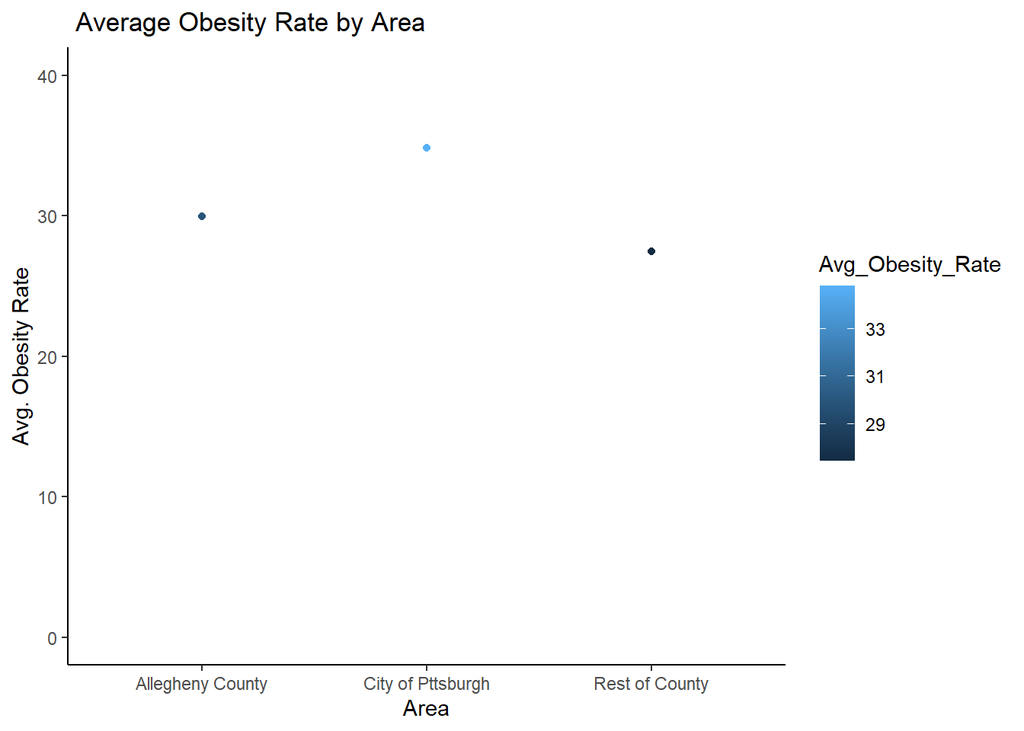

```r
ggplot(data = mean_df, aes(x = Area, y = Avg_Obesity_Rate))+
  geom_point(aes(color = Avg_Obesity_Rate)) +
  ylim(0, 40)+
  labs(title =" Average Obesity Rate by Area", x = "Area", y = "Avg. Obesity Rate")+
  theme_classic()
```

## Standard Deviation

Let’s look at the amount of variation within our datasets.

```r
# sd(obesity_rate)
# sd(pitt_obesity)
# sd(roc_obesity)

cat("The standard deviation of obesity rates within the entire county is ", sd(obesity_rate), ".", '\n', sep ="")
```

```
## The standard deviation of obesity rates within the entire county is 0.1132584.
```

```r
cat("The standard deviation of obestiy rates within Pittsburgh is ", sd(pitt_obesity), ".", '\n', sep="")
```

```
## The standard deviation of obestiy rates within Pittsburgh is 0.1594621.
```

```r
cat('The standard deviation of obesity rates outside the city of Pittsburgh is ', sd(roc_obesity), ".", '\n', sep ="")
```

```
## The standard deviation of obesity rates outside the city of Pittsburgh is 0.06776408.
```

We can see that there is more variation in the obesity rates within the city than in the rest of the county.

## More Graphs!

We’ll look at some box plots to view the spread of our data.

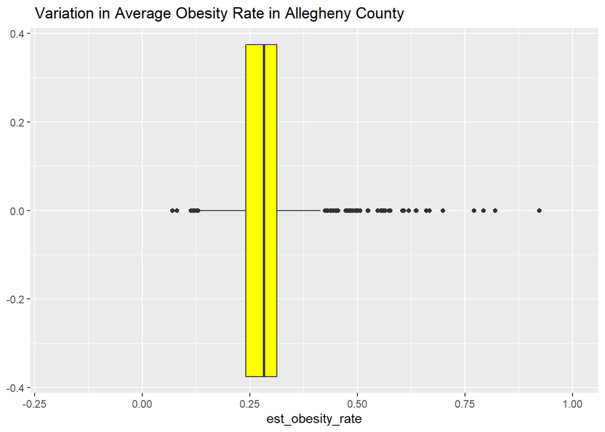

```r
ggplot(data = obesity, aes(x=est_obesity_rate))+
  geom_boxplot(fill = "yellow")+
  labs(title =" Variation in Average Obesity Rate in Allegheny County")+
  xlim(-0.2, 1) # set x axis
```

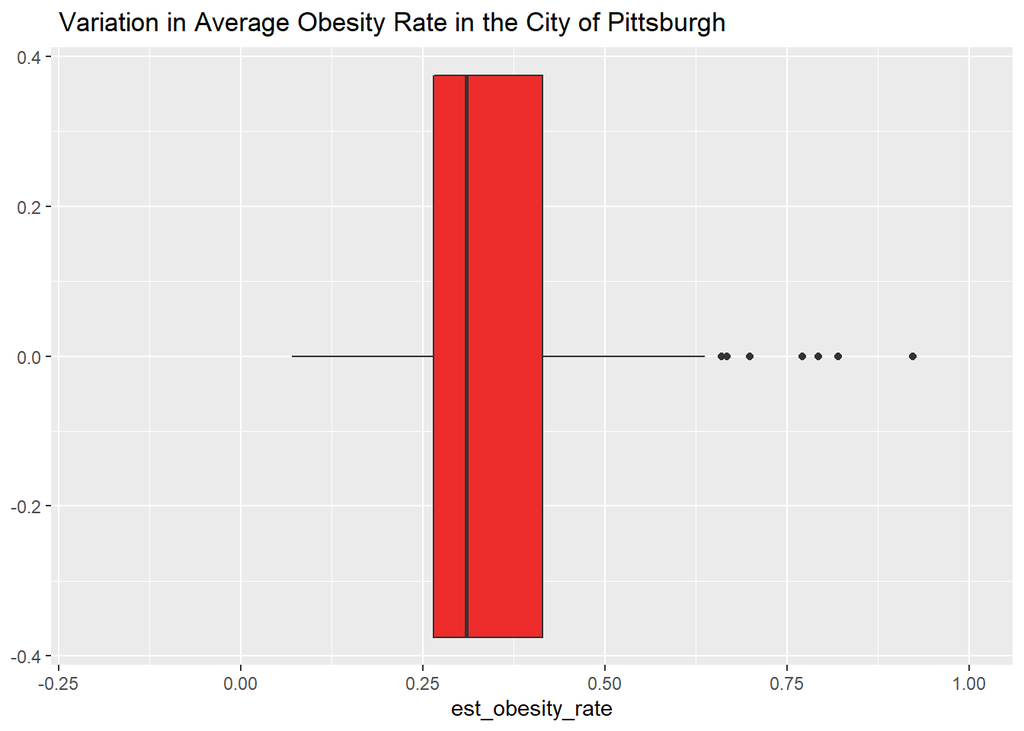

```r
ggplot(data = pitt_df, aes(x = est_obesity_rate))+
  geom_boxplot(fill = "firebrick2")+
  labs(title =" Variation in Average Obesity Rate in the City of Pittsburgh")+
  xlim(-0.2, 1) # set x axis the same for each graph
```

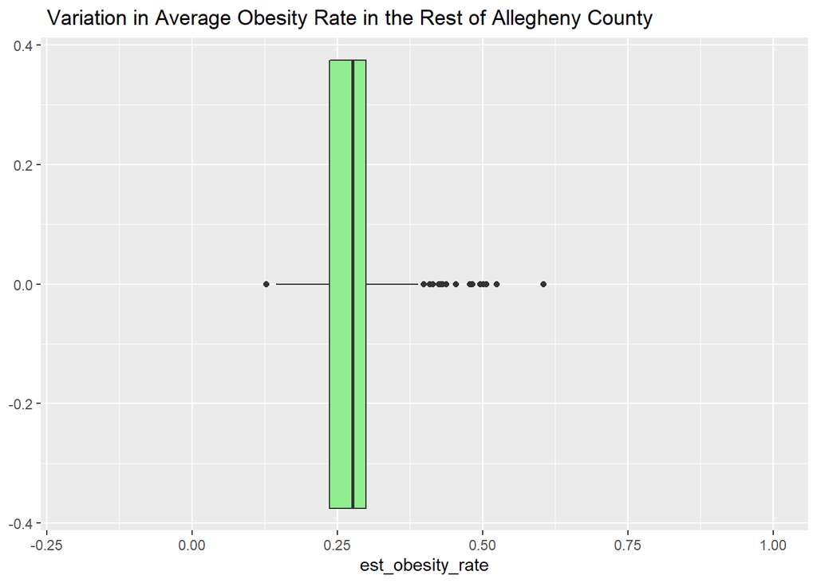

```r
ggplot(data = rest_of_county, aes(x = est_obesity_rate))+
  geom_boxplot(fill = "lightgreen")+
  labs(title =" Variation in Average Obesity Rate in the Rest of Allegheny County")+
  xlim(-0.2, 1) # set x axis the same for each graph
```

## Pittsburgh

Let’s get a little more information about obesity rates within the city. First we’ll plot by neighborhood.

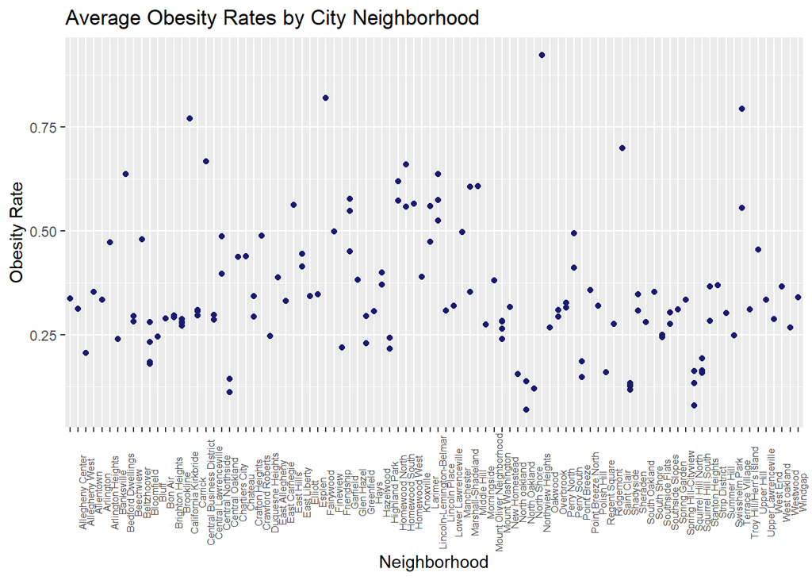

```r
ggplot(data = pitt_df, aes(x = city_neighborhood, y = est_obesity_rate))+
         geom_point(color = "midnightblue")+
  theme(axis.text.x = element_text(angle = 90, size = 6))+ # change angle and size of text
  labs(title = "Average Obesity Rates by City Neighborhood", x = "Neighborhood", y = "Obesity Rate")
```

```r
highest <- pitt_df$est_obesity_rate > 0.65 # create TF vector to filter out obestity rates higher than 65%

highest_rates <- pitt_df[highest, ] # apply vector to Pittsburgh dataset
highest_rates # create new df
```

```
##           stname   tractfips Tract_2000 Tract_2010 municipality
## 2   Pennsylvania 42003020100      20100            Pittsburgh
## 14  Pennsylvania 42003051100      51100            Pittsburgh
## 47  Pennsylvania 42003130400     130400            Pittsburgh
## 85  Pennsylvania 42003250700     250700            Pittsburgh
## 89  Pennsylvania 42003260900     260900            Pittsburgh
## 367 Pennsylvania 42003561700     160600     561700 Pittsburgh
## 386 Pennsylvania 42003563000     280800     563000 Pittsburgh
##             city_neighborhood est_obesity_rate is_pittsburgh
## 2   Central Business District        0.6680120             1
## 14            Terrace Village        0.7931330             1
## 47             Homewood South        0.6605847             1
## 85       California Kirkbride        0.7710464             1
## 89          Northview Heights        0.9229324             1
## 367               Saint Clair        0.6995004             1
## 386                 Fairywood        0.8203114             1
```

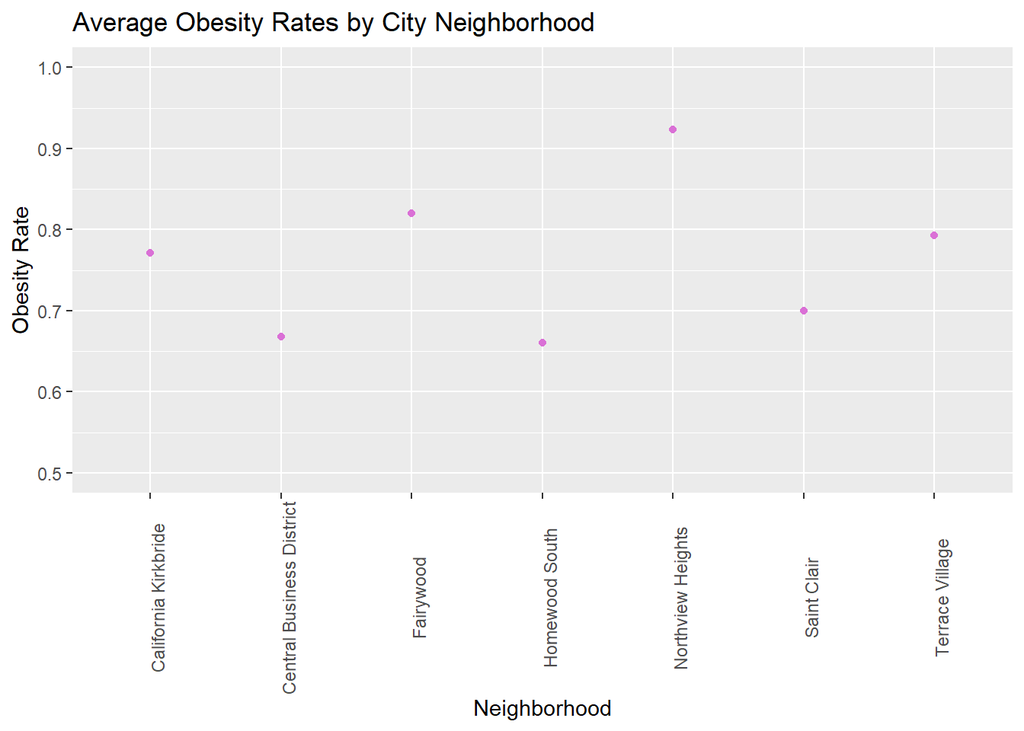

```r
ggplot(data = highest_rates, aes(x = city_neighborhood, y = est_obesity_rate))+
         geom_point(color = "orchid")+
  theme(axis.text.x = element_text(angle = 90))+
  labs(title = "Average Obesity Rates by City Neighborhood", x = "Neighborhood", y = "Obesity Rate")+
  ylim(0.5, 1)
```

Let’s look at the rest of the county…

```r
highest_roc <- rest_of_county$est_obesity_rate > 0.65 # create TF vector to filter out obestity rates higher than 65%

highest_rates_roc <- rest_of_county[highest_roc, ] # apply vector to Pittsburgh dataset
highest_rates_roc
```

```
## [1] stname            tractfips         Tract_2000        Tract_2010
## [5] municipality      city_neighborhood est_obesity_rate  is_pittsburgh
## <0 rows> (or 0-length row.names)
```

There are no municipalities outside the city that have an estimated obesity rate of higher than 65%.

## Conclusion

Further analysis is needed to determine the cause of the differences in obesity rates within and outside the City of Pittsburgh. My suggestion for future analysis would be to look at income levels in municipalities within Allegheny County, as well as the proximity of grocery stores to each municipality. These, along with other factors, would allow for a more nuanced understanding of this data.